# Investigation of differential gene expression in muscle tissue among men and women

## Material and Methods - Cleaning the data

**No. of rows x no. of columns before cleaning**

- Subject phenotypes: 980 x 4
- Sample attributes: 22951 x 63
- Gene reads: 500 x 9112

**No. of rows x no. of columns after cleaning**

- Subject phenotypes: 980 x 4
- Sample attributes: 9111 x 8
- Gene reads: 499 x 9112

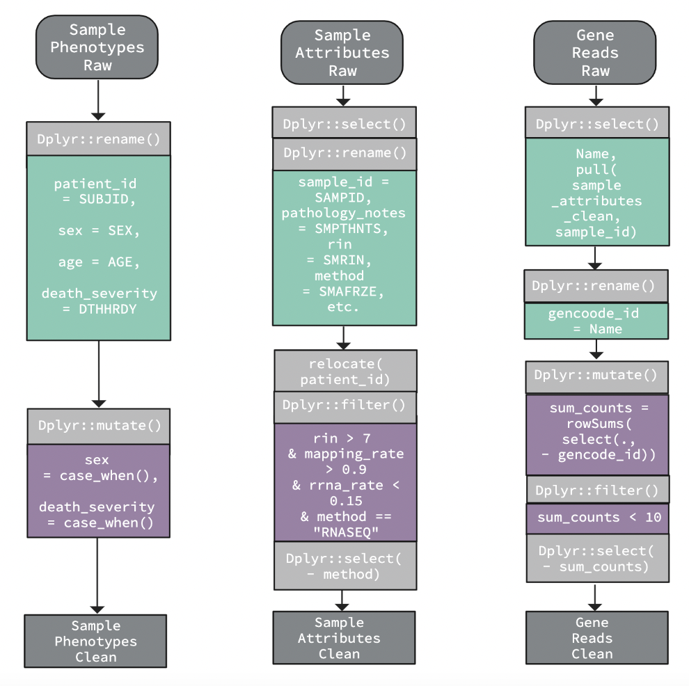

## Material and Methods - Augmentation

**No. of rows x no. of columns before cleaning**

- Subject phenotypes: 980 x 4
- Subject attributes: 22951 x 63
- Gene reads: 500 x 9112

**No. of rows x no. of columns after cleaning**

- Subject phenotypes: 980 x 4
- Sample attributes: 524 x 11
- Gene reads: 524 x 500
  - There are 524 patients in the final data frames

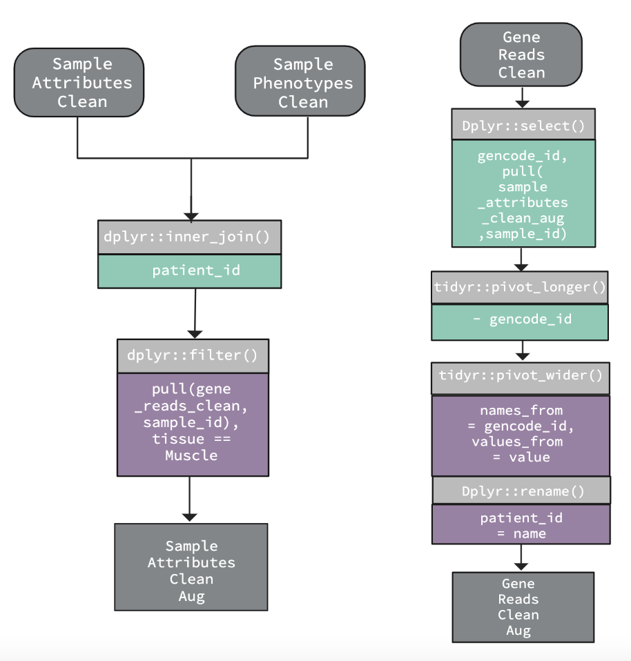